# Loan Data Exploration

## Preliminary Wrangling

This data set contains 113,937 loans with 81 variables on each loan, including loan amount, borrower rate (or interest rate), current loan status, borrower income, and many others attributes.

```python
# import all packages and set plots to be embedded inline
import numpy as np
import pandas as pd
import matplotlib.pyplot as plt
import seaborn as sb

%matplotlib inline
```

```python
# load in the dataset into a pandas dataframe
Loans = pd.read_csv('prosperLoanData.csv')
```

```python
# high-level overview of data shape and composition
print(Loans.shape)
print(Loans.dtypes)
print(Loans.head(10))
```

```
(113937, 81)
ListingKey                              object
ListingNumber                            int64
ListingCreationDate                     object
CreditGrade                             object
Term                                     int64
LoanStatus                              object
ClosedDate                              object
BorrowerAPR                            float64
BorrowerRate                           float64
LenderYield                            float64
EstimatedEffectiveYield                float64
EstimatedLoss                          float64
EstimatedReturn                        float64
ProsperRating (numeric)                float64
ProsperRating (Alpha)                   object
ProsperScore                           float64
ListingCategory (numeric)                int64
BorrowerState                           object
Occupation                              object
EmploymentStatus                        object
EmploymentStatusDuration               float64
IsBorrowerHomeowner                       bool
CurrentlyInGroup                          bool
GroupKey                                object
DateCreditPulled                        object
CreditScoreRangeLower                  float64
CreditScoreRangeUpper                  float64
FirstRecordedCreditLine                 object
CurrentCreditLines                     float64
OpenCreditLines                        float64
                                        ...
TotalProsperLoans                      float64
TotalProsperPaymentsBilled             float64
OnTimeProsperPayments                  float64
ProsperPaymentsLessThanOneMonthLate    float64
ProsperPaymentsOneMonthPlusLate        float64
ProsperPrincipalBorrowed               float64
ProsperPrincipalOutstanding            float64
ScorexChangeAtTimeOfListing            float64
```

[output cut: 81 more lines]

```
9            1.0                0                          0

  InvestmentFromFriendsAmount Investors
0                         0.0       258
1                         0.0         1
2                         0.0        41
3                         0.0       158
4                         0.0        20
5                         0.0         1
6                         0.0         1
7                         0.0         1
8                         0.0         1
9                         0.0         1

[10 rows x 81 columns]
```

```python
#Print data frame statics.
Loans.describe()
```

|  | ListingNumber | Term | BorrowerAPR | BorrowerRate | LenderYield | EstimatedEffectiveYield | EstimatedLoss | EstimatedReturn | ProsperRating (numeric) | ProsperScore | ... | LP_ServiceFees | LP_CollectionFees | LP_GrossPrincipalLoss | LP_NetPrincipalLoss | LP_NonPrincipalRecoverypayments | PercentFunded | Recommendations | InvestmentFromFriendsCount | InvestmentFromFriendsAmount | Investors |
| --- | --- | --- | --- | --- | --- | --- | --- | --- | --- | --- | --- | --- | --- | --- | --- | --- | --- | --- | --- | --- | --- |
| count | 1.139370e+05 | 113937.000000 | 113912.000000 | 113937.000000 | 113937.000000 | 84853.000000 | 84853.000000 | 84853.000000 | 84853.000000 | 84853.000000 | ... | 113937.000000 | 113937.000000 | 113937.000000 | 113937.000000 | 113937.000000 | 113937.000000 | 113937.000000 | 113937.000000 | 113937.000000 | 113937.000000 |
| mean | 6.278857e+05 | 40.830248 | 0.218828 | 0.192764 | 0.182701 | 0.168661 | 0.080306 | 0.096068 | 4.072243 | 5.950067 | ... | -54.725641 | -14.242698 | 700.446342 | 681.420499 | 25.142686 | 0.998584 | 0.048027 | 0.023460 | 16.550751 | 80.475228 |
| std | 3.280762e+05 | 10.436212 | 0.080364 | 0.074818 | 0.074516 | 0.068467 | 0.046764 | 0.030403 | 1.673227 | 2.376501 | ... | 60.675425 | 109.232758 | 2388.513831 | 2357.167068 | 275.657937 | 0.017919 | 0.332353 | 0.232412 | 294.545422 | 103.239020 |
| min | 4.000000e+00 | 12.000000 | 0.006530 | 0.000000 | -0.010000 | -0.182700 | 0.004900 | -0.182700 | 1.000000 | 1.000000 | ... | -664.870000 | -9274.750000 | -94.200000 | -954.550000 | 0.000000 | 0.700000 | 0.000000 | 0.000000 | 0.000000 | 1.000000 |
| 25% | 4.009190e+05 | 36.000000 | 0.156290 | 0.134000 | 0.124200 | 0.115670 | 0.042400 | 0.074080 | 3.000000 | 4.000000 | ... | -73.180000 | 0.000000 | 0.000000 | 0.000000 | 0.000000 | 1.000000 | 0.000000 | 0.000000 | 0.000000 | 2.000000 |
| 50% | 6.005540e+05 | 36.000000 | 0.209760 | 0.184000 | 0.173000 | 0.161500 | 0.072400 | 0.091700 | 4.000000 | 6.000000 | ... | -34.440000 | 0.000000 | 0.000000 | 0.000000 | 0.000000 | 1.000000 | 0.000000 | 0.000000 | 0.000000 | 44.000000 |
| 75% | 8.926340e+05 | 36.000000 | 0.283810 | 0.250000 | 0.240000 | 0.224300 | 0.112000 | 0.116600 | 5.000000 | 8.000000 | ... | -13.920000 | 0.000000 | 0.000000 | 0.000000 | 0.000000 | 1.000000 | 0.000000 | 0.000000 | 0.000000 | 115.000000 |
| max | 1.255725e+06 | 60.000000 | 0.512290 | 0.497500 | 0.492500 | 0.319900 | 0.366000 | 0.283700 | 7.000000 | 11.000000 | ... | 32.060000 | 0.000000 | 25000.000000 | 25000.000000 | 21117.900000 | 1.012500 | 39.000000 | 33.000000 | 25000.000000 | 1189.000000 |

8 rows × 61 columns

```python
#To find the null values
Loans.isnull().sum()
```

```
ListingKey                                  0
ListingNumber                               0
ListingCreationDate                         0
CreditGrade                             84984
Term                                        0
LoanStatus                                  0
ClosedDate                              58848
BorrowerAPR                                25
BorrowerRate                                0
LenderYield                                 0
EstimatedEffectiveYield                 29084
EstimatedLoss                           29084
EstimatedReturn                         29084
ProsperRating (numeric)                 29084
ProsperRating (Alpha)                   29084
ProsperScore                            29084
ListingCategory (numeric)                   0
BorrowerState                            5515
Occupation                               3588
EmploymentStatus                         2255
EmploymentStatusDuration                 7625
IsBorrowerHomeowner                         0
CurrentlyInGroup                            0
GroupKey                               100596
DateCreditPulled                            0
CreditScoreRangeLower                     591
CreditScoreRangeUpper                     591
FirstRecordedCreditLine                   697
CurrentCreditLines                       7604
OpenCreditLines                          7604
                                        ...
TotalProsperLoans                       91852
TotalProsperPaymentsBilled              91852
OnTimeProsperPayments                   91852
ProsperPaymentsLessThanOneMonthLate     91852
ProsperPaymentsOneMonthPlusLate         91852
ProsperPrincipalBorrowed                91852
ProsperPrincipalOutstanding             91852
ScorexChangeAtTimeOfListing             95009
LoanCurrentDaysDelinquent                   0
LoanFirstDefaultedCycleNumber           96985
LoanMonthsSinceOrigination                  0
LoanNumber                                  0
LoanOriginalAmount                          0
LoanOriginationDate                         0
LoanOriginationQuarter                      0
MemberKey                                   0
MonthlyLoanPayment                          0
LP_CustomerPayments                         0
LP_CustomerPrincipalPayments                0
LP_InterestandFees                          0
LP_ServiceFees                              0
LP_CollectionFees                           0
LP_GrossPrincipalLoss                       0
LP_NetPrincipalLoss                         0
LP_NonPrincipalRecoverypayments             0
PercentFunded                               0
Recommendations                             0
InvestmentFromFriendsCount                  0
InvestmentFromFriendsAmount                 0
Investors                                   0
Length: 81, dtype: int64
```

```python
#Lets quickly look at the Missing values in Borrower APR rate entries here.
Null_filter=Loans.BorrowerAPR.isnull()
Loans.loc[Null_filter,:]
```

|  | ListingKey | ListingNumber | ListingCreationDate | CreditGrade | Term | LoanStatus | ClosedDate | BorrowerAPR | BorrowerRate | LenderYield | ... | LP_ServiceFees | LP_CollectionFees | LP_GrossPrincipalLoss | LP_NetPrincipalLoss | LP_NonPrincipalRecoverypayments | PercentFunded | Recommendations | InvestmentFromFriendsCount | InvestmentFromFriendsAmount | Investors |
| --- | --- | --- | --- | --- | --- | --- | --- | --- | --- | --- | --- | --- | --- | --- | --- | --- | --- | --- | --- | --- | --- |
| 2543 | 044B3365298516680DA929B | 36 | 2005-11-28 22:42:42.557000000 | HR | 36 | Completed | 2006-01-06 00:00:00 | NaN | 0.10000 | 0.0950 | ... | -4.02 | 0.0000 | 0.0 | 0.0 | 0.0 | 1.000 | 0 | 0 | 0.0 | 5 |
| 14632 | E4103364750435927B6F892 | 67 | 2006-01-06 12:54:51.887000000 | AA | 36 | Completed | 2006-04-10 00:00:00 | NaN | 0.06500 | 0.0550 | ... | -2.59 | 0.0000 | 0.0 | 0.0 | 0.0 | 1.000 | 0 | 0 | 0.0 | 5 |
| 25166 | B3083364738592238DBDA63 | 6 | 2005-11-15 16:06:47.457000000 | AA | 36 | Completed | 2005-11-29 00:00:00 | NaN | 0.04350 | 0.0385 | ... | -0.42 | 0.0000 | 0.0 | 0.0 | 0.0 | 1.000 | 0 | 0 | 0.0 | 3 |
| 25330 | B6C33364979883097BBCD77 | 39 | 2005-11-29 13:29:16.810000000 | AA | 36 | Completed | 2006-03-21 00:00:00 | NaN | 0.06395 | 0.0552 | ... | -1.30 | 0.0000 | 0.0 | 0.0 | 0.0 | 1.000 | 0 | 0 | 0.0 | 4 |
| 29773 | 3480336511078238810A782 | 21 | 2005-11-18 14:48:19.753000000 | AA | 36 | Completed | 2008-06-05 00:00:00 | NaN | 0.06000 | 0.0550 | ... | -16.08 | 0.0000 | 0.0 | 0.0 | 0.0 | 1.000 | 0 | 0 | 0.0 | 10 |
| 39870 | B6E73366056348939D8801F | 24 | 2005-11-20 14:45:55.193000000 | C | 36 | Completed | 2006-10-24 00:00:00 | NaN | 0.12000 | 0.1150 | ... | -53.96 | 0.0000 | 0.0 | 0.0 | 0.0 | 1.000 | 0 | 0 | 0.0 | 6 |
| 43587 | 2F123364529418907A58D4C | 19 | 2005-11-18 14:16:59.093000000 | AA | 36 | Completed | 2005-11-29 00:00:00 | NaN | 0.08500 | 0.0750 | ... | -1.10 | 0.0000 | 0.0 | 0.0 | 0.0 | 1.000 | 0 | 0 | 0.0 | 6 |
| 62297 | 2F25336514614362295DA03 | 7 | 2005-11-15 18:25:56.107000000 | E | 36 | Completed | 2005-11-30 00:00:00 | NaN | 0.17000 | 0.1150 | ... | -0.42 | 0.0000 | 0.0 | 0.0 | 0.0 | 1.000 | 0 | 0 | 0.0 | 1 |
| 71280 | DED033645500376547AF34E | 60 | 2005-12-29 19:53:41 | C | 36 | Completed | 2008-04-21 00:00:00 | NaN | 0.09000 | 0.0850 | ... | -74.98 | 0.0000 | 0.0 | 0.0 | 0.0 | 1.000 | 0 | 0 | 0.0 | 8 |
| 71875 | F50A33647261871547E3E0D | 68 | 2006-01-06 13:05:50.890000000 | AA | 36 | Completed | 2006-07-11 00:00:00 | NaN | 0.07000 | 0.0650 | ... | -6.01 | 0.0000 | 0.0 | 0.0 | 0.0 | 1.000 | 0 | 0 | 0.0 | 1 |
| 73945 | 8D5F33655433257693D8033 | 18 | 2005-11-18 14:10:50.470000000 | HR | 36 | Completed | 2006-01-06 00:00:00 | NaN | 0.25000 | 0.2450 | ... | -2.08 | 0.0000 | 0.0 | 0.0 | 0.0 | 1.000 | 0 | 0 | 0.0 | 1 |
| 74114 | 0B4133652604109810CAA3B | 34 | 2005-11-28 16:16:35.077000000 | AA | 36 | Completed | 2008-12-08 00:00:00 | NaN | 0.06000 | 0.0550 | ... | -7.61 | 0.0000 | 0.0 | 0.0 | 0.0 | 1.000 | 0 | 0 | 0.0 | 7 |
| 75710 | F7C53365521712881842072 | 25 | 2005-11-20 20:15:47.240000000 | C | 36 | Completed | 2005-11-30 00:00:00 | NaN | 0.10000 | 0.0750 | ... | -0.88 | 0.0000 | 0.0 | 0.0 | 0.0 | 1.000 | 0 | 0 | 0.0 | 3 |
| 78414 | 468C3366438848688B8B5B4 | 22 | 2005-11-18 16:35:48.210000000 | AA | 36 | Completed | 2006-01-09 00:00:00 | NaN | 0.13000 | 0.1250 | ... | -1.68 | 0.0000 | 0.0 | 0.0 | 0.0 | 1.000 | 0 | 0 | 0.0 | 2 |
| 80369 | 54A833661083301426FFC90 | 44 | 2005-12-03 14:03:22.207000000 | AA | 36 | Completed | 2006-01-06 00:00:00 | NaN | 0.06500 | 0.0550 | ... | -1.12 | 0.0000 | 0.0 | 0.0 | 0.0 | 1.000 | 0 | 0 | 0.0 | 10 |
| 81848 | 584D3364403680278BB6704 | 28 | 2005-11-21 19:35:46.890000000 | D | 36 | Completed | 2008-03-18 00:00:00 | NaN | 0.13000 | 0.0950 | ... | -25.67 | -123.3229 | 0.0 | 0.0 | 0.0 | 1.000 | 0 | 0 | 0.0 | 4 |
| 90598 | B87F3364623805558A45EAB | 16 | 2005-11-18 13:39:03.263000000 | B | 36 | Completed | 2005-11-29 00:00:00 | NaN | 0.12000 | 0.1150 | ... | -0.33 | 0.0000 | 0.0 | 0.0 | 0.0 | 1.000 | 0 | 0 | 0.0 | 4 |
| 92516 | 80373365765621932269C34 | 48 | 2005-12-05 13:58:06.017000000 | AA | 36 | Completed | 2008-07-06 00:00:00 | NaN | 0.07000 | 0.0650 | ... | -23.12 | 0.0000 | 0.0 | 0.0 | 0.0 | 1.000 | 0 | 0 | 0.0 | 5 |
| 103509 | 0E0F336443449038617E9F4 | 59 | 2005-12-21 19:37:33.813000000 | A | 36 | Completed | 2008-12-30 00:00:00 | NaN | 0.09450 | 0.0845 | ... | -69.17 | 0.0000 | 0.0 | 0.0 | 0.0 | 1.011 | 0 | 0 | 0.0 | 14 |
| 105925 | B01233643651103736EE3B6 | 20 | 2005-11-18 14:22:34.763000000 | AA | 36 | Completed | 2005-12-28 00:00:00 | NaN | 0.08500 | 0.0750 | ... | -2.38 | 0.0000 | 0.0 | 0.0 | 0.0 | 1.000 | 0 | 0 | 0.0 | 6 |
| 106465 | B8D63366141679436131B1C | 23 | 2005-11-20 13:21:31.993000000 | NC | 36 | Completed | 2006-01-06 00:00:00 | NaN | 0.09000 | 0.0850 | ... | -4.00 | 0.0000 | 0.0 | 0.0 | 0.0 | 1.000 | 0 | 0 | 0.0 | 1 |
| 106735 | 97B333660731451030726AF | 5 | 2005-11-11 08:46:17.303000000 | AA | 36 | Completed | 2006-02-07 00:00:00 | NaN | 0.05950 | 0.0545 | ... | -0.84 | 0.0000 | 0.0 | 0.0 | 0.0 | 1.000 | 0 | 0 | 0.0 | 5 |
| 109027 | F59D33647178242776CD53B | 40 | 2005-11-29 20:23:22.770000000 | AA | 36 | Completed | 2006-01-06 00:00:00 | NaN | 0.06000 | 0.0550 | ... | -1.24 | 0.0000 | 0.0 | 0.0 | 0.0 | 1.000 | 0 | 0 | 0.0 | 8 |
| 111607 | 84CC3365208034255DDCB47 | 35 | 2005-11-28 17:25:43.160000000 | B | 36 | Completed | 2005-12-08 00:00:00 | NaN | 0.06500 | 0.0600 | ... | -0.53 | 0.0000 | 0.0 | 0.0 | 0.0 | 1.000 | 0 | 0 | 0.0 | 5 |
| 113921 | D21A33647075665665BE266 | 4 | 2005-11-09 20:44:28.847000000 | AA | 36 | Completed | 2005-11-25 00:00:00 | NaN | 0.04000 | 0.0350 | ... | -0.88 | 0.0000 | 0.0 | 0.0 | 0.0 | 1.000 | 0 | 0 | 0.0 | 1 |

25 rows × 81 columns

while do a investigating the about 25 records .it seems the loan records related to 36 Term and all of the are completed state.So it is really not worthy to have for our futher validation and it will make raise an issue when we add in BIN parameter in hist plot.

```python
## Data wrangling & Cleaning process to have selective records to do further analaysis.
Loans =Loans.loc[-Null_filter,:]
```

```python
# convert CreditGrade, ProsperRating, and IncomeRange into ordered categorical types
ordinal_var_dict = {'CreditGrade': ['AA','A','B','C','D','E','HR','NC'],
                    'ProsperRating (Alpha)': ['AA','A','B','C','D','E','HR'],
                    'IncomeRange': ['$0', 'Not employed', '$1-24,999', '$25,000-49,999', '$50,000-74,999', '$75,000-99,999', '$100,000+']}

for var in ordinal_var_dict:
    pd_ver = pd.__version__.split(".")
    if (int(pd_ver[0]) > 0) or (int(pd_ver[1]) >= 21): # v0.21 or later
        ordered_var = pd.api.types.CategoricalDtype(ordered = True,
                                                    categories = ordinal_var_dict[var])
        Loans[var] = Loans[var].astype(ordered_var)
    else: # pre-v0.21
        Loans[var] = Loans[var].astype('category', ordered = True,
                                             categories = ordinal_var_dict[var])
```

```python
# To define a function to add one new purpose of the loan descripton column . Which will help to make Easy readable visualization.
def Loan_purpose(x):
    """ quick function for getting the Loan purpose description based on number"""
    list_values = ['Not Available','Debt Consolidation','Home Improvement','Business','Personal Loan','Student Use','Auto','Other','Baby&Adoption','Boat',
             'Cosmetic Procedure', 'Engagement Ring','Green Loans','Household Expenses','Large Purchases','Medical/Dental','Motorcycle',
             'RV','Taxes','Vacation','Wedding Loans'];

    return list_values[x];

Loans['category'] = Loans['ListingCategory (numeric)'].apply(Loan_purpose)
```

### What is the structure of your dataset?

There are 1,13,937 Loans in the dataset with 81 features (LoanOriginalAmount,BorrowerAPR,BorrowerRate,ProsperRating (numeric),TotalProsperLoans,StatedMonthlyIncome,ClosedDate,Etc). Most variables are folating & objects in nature, but the variables CreditGrade, ProsperRating, and IncomeRange are ordered factor variables with the following levels.

CreditGrade: ['AA','A','B','C','D','E','HR','NC'], ProsperRating : ['AA','A','B','C','D','E','HR'], IncomeRange : ['$0', 'Not employed', '$1-24,999', '$25,000-49,999', '$50,000-74,999', '$75,000-99,999', '$100,000+']

### What is/are the main feature(s) of interest in your dataset?

#### I'm most interested in figuring out what features are best for defining the interest rate of Loans in the dataset.

#### What are the factors to define the loan Amount ?

#### Which states was buying More loans ?

### What features in the dataset do you think will help support your investigation into your feature(s) of interest?

I expect that Loan Amount,Term,Listing Category,Credit Rating & Proper Rating will have the strongest prediction on each Loan s records:I also think that the other IncomeRange,StatedMonthlyIncome,occupation will have define the interest rate.

## Univariate Exploration

I'll start by looking at the distribution of the main variable of interest: BorrowerRate & BorrowerAPR

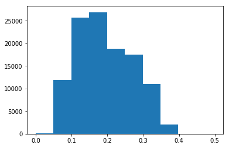

```python
# plotting interest rate on a standard scale
binsize = 0.05
plt.hist(data = Loans, x = 'BorrowerRate');
```

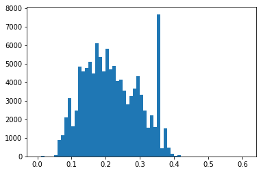

```python
#let plot the BrrowerAPR to find the destribution
bin_edges = np.arange(0, Loans['BorrowerAPR'].max()+0.1, 0.01)
plt.hist(data =Loans , x = 'BorrowerAPR', bins = bin_edges);
```

Quick obersvation here , 0.3 to 0.4 ,there is one lenghy bar shown .So i will do more analysis on this areas.

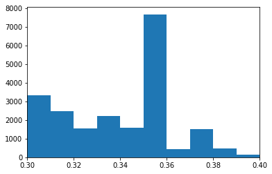

```python
bin_edges = np.arange(0.3, 0.4, 0.01)
plt.hist(data = Loans, x = 'BorrowerAPR', bins = bin_edges);
plt.xlim(0.3, 0.4) ;
```

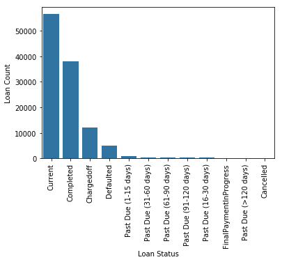

```python
# lets review the loan status count overview here .
base_color = sb.color_palette()[0]
cat_order = Loans['LoanStatus'].value_counts().index
sb.countplot(data = Loans, x= 'LoanStatus', color = base_color, order = cat_order)
plt.xlabel('Loan Status')
plt.ylabel('Loan Count')
plt.xticks(rotation = 90);
```

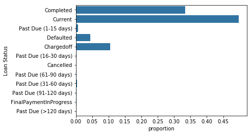

```python
# let's do more analysis with floating x variables to see more in details about this view.
# of tick marks
n_points = Loans.shape[0]
max_count = Loans['LoanStatus'].value_counts().max()
max_prop = max_count / n_points

# generate tick mark locations and names
tick_props = np.arange(0, max_prop, 0.05)
tick_names = ['{:0.2f}'.format(v) for v in tick_props]

# create the plot
base_color = sb.color_palette()[0]
sb.countplot(data = Loans, y = 'LoanStatus', color = base_color)
plt.xticks(tick_props * n_points, tick_names)
plt.xlabel('proportion')
plt.ylabel('Loan Status');
```

Quick Catch here : We dont able to find the proper bar count after the charged off status .so lets do more analysis on it.

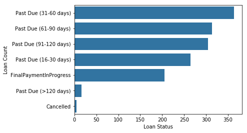

```python
# Just filter the few loan status which we need to see deeply on it.
df_status=Loans.query('LoanStatus in ["Past Due (31-60 days)", "Past Due (61-90 days)","Past Due (91-120 days)","Past Due (16-30 days)","FinalPaymentInProgress","Past Due (>120 days)","Cancelled"]')
df_status.LoanStatus.value_counts()
base_color = sb.color_palette()[0]
cat_order = df_status['LoanStatus'].value_counts().index
sb.countplot(data = df_status, y= 'LoanStatus', color = base_color, order = cat_order)
plt.xlabel('Loan Status')
plt.ylabel('Loan Count');
```

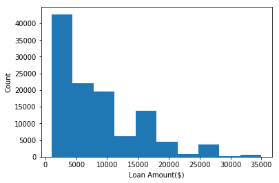

```python
#LoanOriginalAmount overiew
plt.hist(data = Loans, x = 'LoanOriginalAmount');
plt.xlabel('Loan Amount($)')
plt.ylabel('Count');
```

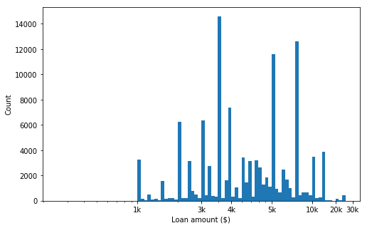

```python
# there's a long tail in the distribution, so let's put it on a log scale instead
log_binsize = 0.025
bins = 10 ** np.arange(2.4, np.log10(Loans['LoanOriginalAmount'].max())+log_binsize, log_binsize)
plt.figure(figsize=[8, 5])
plt.hist(data = Loans, x = 'LoanOriginalAmount', bins = bins)
plt.xscale('log')
plt.xticks([1e3,3e3,5e3, 1e4, 2e4,3e4,4e4], ['1k','3k', '4k', '5k', '10k', '20k','30k','40k'])
plt.xlabel('Loan amount ($)')
plt.ylabel('Count')
plt.show()
```

Next up, the first predictor variable of interest: ProsperRating (numeric),ProsperRating (Alpha),ProsperScore

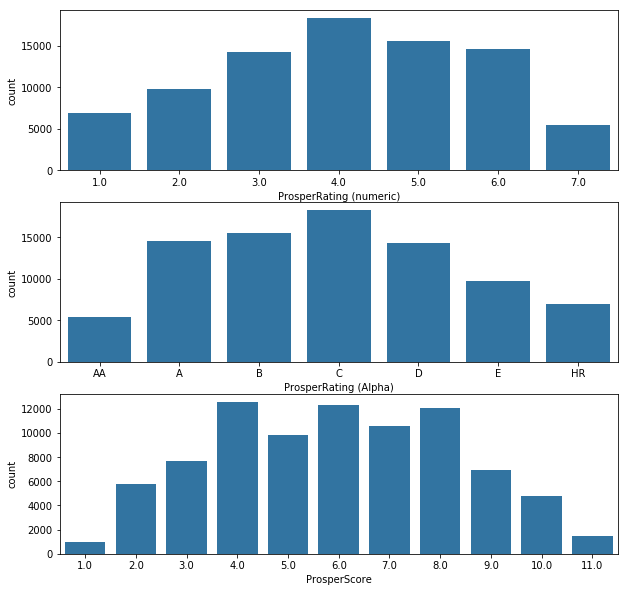

```python
# let's plot all three together to get an idea of each ProsperRating (numeric),ProsperRating (Alpha),ProsperScore distribution.

# 0 - N/A, 1 - HR, 2 - E, 3 - D, 4 - C, 5 - B, 6 - A, 7 - AA
fig, ax = plt.subplots(nrows=3, figsize = [10,10])
default_color = sb.color_palette()[0]
sb.countplot(data = Loans, x = 'ProsperRating (numeric)', color = default_color, ax = ax[0])
sb.countplot(data = Loans, x = 'ProsperRating (Alpha)', color = default_color, ax = ax[1])
sb.countplot(data = Loans, x = 'ProsperScore', color = default_color, ax = ax[2])
plt.show()
```

```
Text(0,0.5,'Loan Category')
```

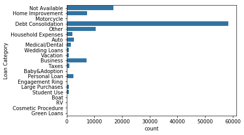

```python
# let's plot the purpose the loan distribution count list.
base_color = sb.color_palette()[0]
list_order=Loans['category'].value_counts().index
sb.countplot(data = Loans, y= 'category', color = base_color)
plt.ylabel('Loan Category')
```

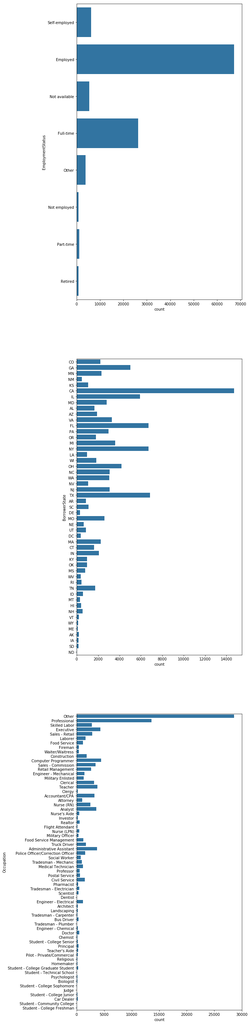

```python
# let's plot all three together to get an idea of each EmploymentStatus,BorrowerState,Occupation variable's distribution.
fig, ax = plt.subplots(nrows=3, figsize = [8,50])
default_color = sb.color_palette()[0]
sb.countplot(data = Loans, y = 'EmploymentStatus', color = default_color, ax = ax[0])
sb.countplot(data = Loans, y = 'BorrowerState', color = default_color, ax = ax[1])
sb.countplot(data = Loans, y = 'Occupation', color = default_color, ax = ax[2])

plt.show()
```

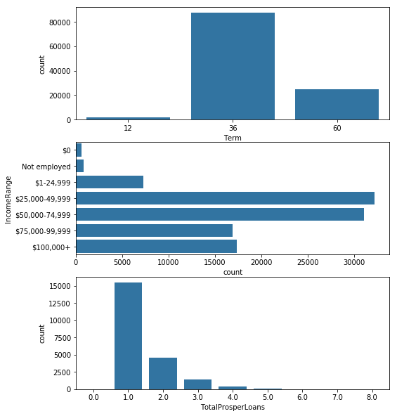

```python
# let's plot all three together to get an idea of Term,IncomeRange,TotalProsperLoans variable's distribution.
fig, ax = plt.subplots(nrows=3, figsize = [8,10])
default_color = sb.color_palette()[0]
sb.countplot(data = Loans, x = 'Term', color = default_color, ax = ax[0])
sb.countplot(data = Loans, y = 'IncomeRange', color = default_color, ax = ax[1])
sb.countplot(data = Loans, x = 'TotalProsperLoans', color = default_color, ax = ax[2])
plt.show()
```

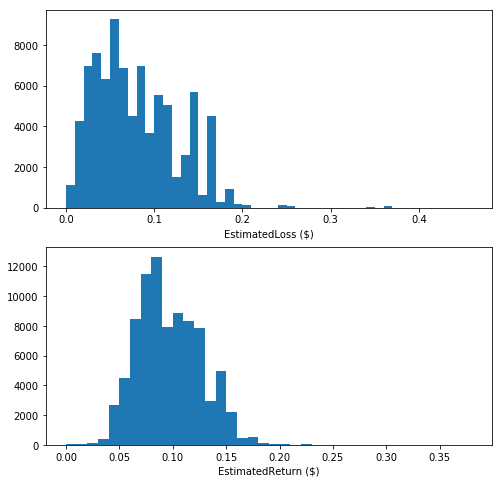

```python
# let's quickly review EstimatedLoss,EstimatedReturn review

fig, ax = plt.subplots(nrows=2, figsize = [8,8])
Null_filter=Loans.EstimatedLoss.isnull()
Est_loss_return =Loans.loc[-Null_filter,:]

variables = ['EstimatedLoss','EstimatedReturn']
for i in range(len(variables)):
  var = variables[i]
  bins = np.arange(0, max(Est_loss_return[var])+0.1, 0.01)
  ax[i].hist(data = Est_loss_return, x = var ,bins=bins)
  ax[i].set_xlabel('{} ($)'.format(var))
plt.show()
```

# Quick observation on this above diagrams.

### Of the features you investigated, were there any unusual distributions? Did you perform any operations on the data to tidy, adjust, or change the form of the data? If so, why did you do this?

When investigating the occupation columdn in dataset , the many entries put an others ,it shows highest volume of data.this will more confused to take right decesion.

## Bivariate Exploration

To start off with, I want to look at the pairwise correlations present between features in the data.

```python
 numeric_vars = ['LoanOriginalAmount','BorrowerAPR','BorrowerRate','ProsperRating (numeric)','TotalProsperLoans','StatedMonthlyIncome']
categoric_vars = ['Term','LoanStatus','CreditGrade','ProsperRating (Alpha)','ListingCategory (numeric)','BorrowerState','Occupation','EmploymentStatus',
'IncomeRange']
```

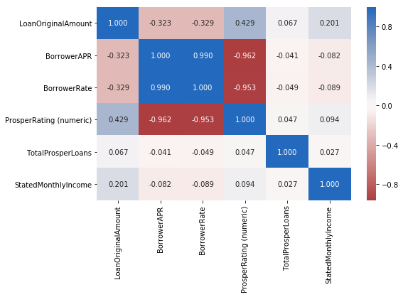

```python
# correlation plot
plt.figure(figsize = [8, 5])
sb.heatmap(Loans[numeric_vars].corr(), annot = True, fmt = '.3f',
           cmap = 'vlag_r', center = 0)
plt.show()
```

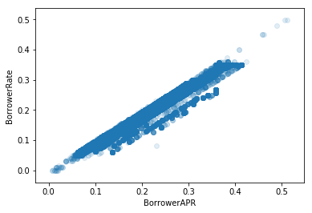

```python
#Co-reation between BorrowerAPR and BorrowerRate
plt.scatter(data = Loans, x = 'BorrowerAPR', y = 'BorrowerRate', alpha = 1/8)
plt.xlabel('BorrowerAPR')
plt.ylabel('BorrowerRate');
```

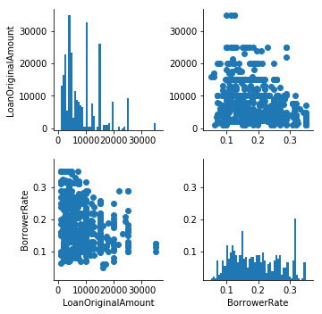

```python
# plot matrix: sample 500 Loans so that plots are clearer
samples = np.random.choice(Loans.shape[0], 500, replace = False)
Loans_samp = Loans.loc[samples,:]
g = sb.PairGrid(data = Loans_samp, vars =  ['LoanOriginalAmount','BorrowerRate'])
g = g.map_diag(plt.hist, bins = 50);
g.map_offdiag(plt.scatter)
```

BorrowerAPR & BorrowerRate rate highly correlated with one another.ButLoan amount and Interest rate not highly correlated with one another

Let's move on to looking at how interest rate correlate with the categorical variables.

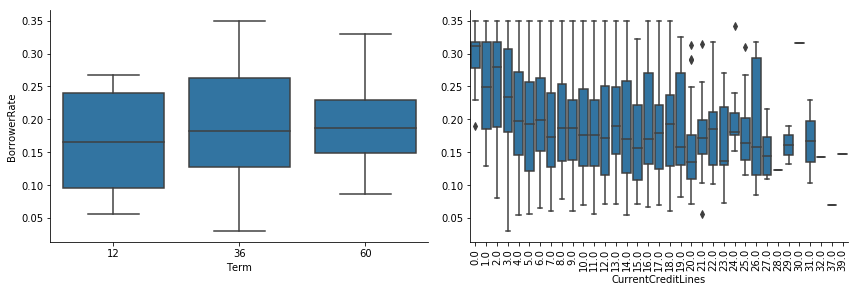

```python
# using box plot to find the relationship between numaric & cateogrical variable.
#
samples = np.random.choice(Loans.shape[0], 2000, replace = False)
Loans_samp = Loans.loc[samples,:]

def boxgrid(x, y, **kwargs):
    """ Quick hack for creating box plots with seaborn's PairGrid. """
    default_color = sb.color_palette()[0]
    sb.boxplot(x, y, color = default_color)

plt.figure(figsize = [40, 40])
g = sb.PairGrid(data = Loans_samp, y_vars = ['BorrowerRate'], x_vars = ['Term','CurrentCreditLines'],
                size = 4, aspect = 1.5)
g.map(boxgrid)
plt.xticks(rotation = 90)
plt.show();
```

Interestingly, it appears 12 month term Barrowers getting less interest rate likely other term shows little high interest rate.

Finally, let's look at relationships between the two categorical features.

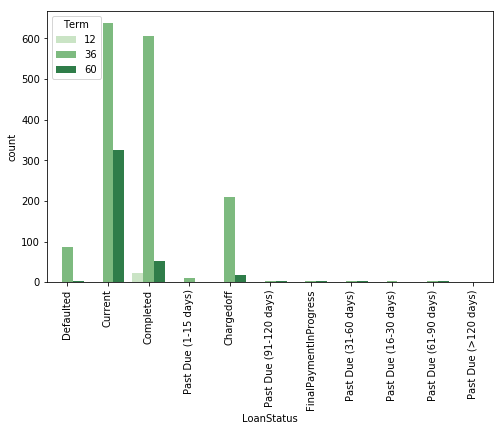

```python
# Lets create a countplot to check the loan status based on Terms.
plt.figure(figsize = [8, 5])
sb.countplot(data = Loans_samp, x = 'LoanStatus', hue = 'Term', palette = 'Greens')
plt.xticks(rotation=90)
plt.show()
```

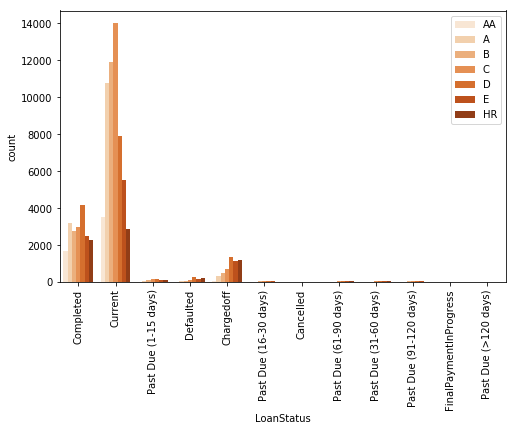

```python
#To see the loan status count based on Prosper Ratings.
plt.figure(figsize = [8, 5])
sb.countplot(data = Loans, x = 'LoanStatus', hue = 'ProsperRating (Alpha)', palette = 'Oranges')
plt.xticks(rotation=90)
plt.legend(loc = 1, ncol = 1)
```

The Charged off status highly shows for 36 & 60 Terms kind of loans. the Current & compleated loans are high ae per Categorical reationship view.

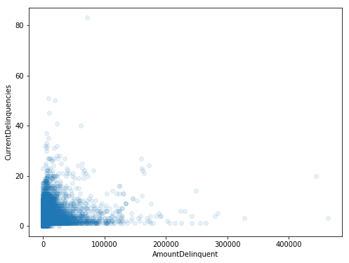

```python
# lets find the relationship with the AmountDelinquent,CurrentDelinquencies variables
plt.figure(figsize = [8, 6])
plt.scatter(data = Loans, x = 'AmountDelinquent', y = 'CurrentDelinquencies', alpha = 1/10)
plt.xlabel('AmountDelinquent')
plt.ylabel('CurrentDelinquencies')
plt.show()
```

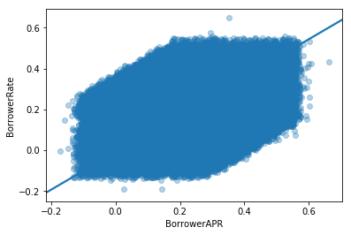

```python
## quickly validating the relationship with using regplot
sb.regplot(data = Loans, x = 'BorrowerAPR', y = 'BorrowerRate', fit_reg = True,
           x_jitter = 0.2, y_jitter = 0.2, scatter_kws = {'alpha' : 1/3})
```

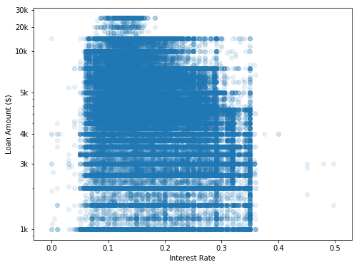

```python
# log overiew for loan amount since the amount is high
plt.figure(figsize = [8, 6])
plt.scatter(data = Loans, x = 'BorrowerRate', y = 'LoanOriginalAmount', alpha = 1/10)
plt.xlabel('Interest Rate')
plt.yscale('log')
plt.yticks([1e3,3e3,5e3, 1e4, 2e4,3e4,4e4], ['1k','3k', '4k', '5k', '10k', '20k','30k','40k'])
plt.ylabel('Loan Amount ($)')
plt.show()
```

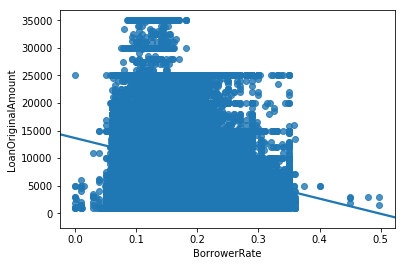

```python
sb.regplot(data = Loans, x = 'BorrowerRate', y = 'LoanOriginalAmount')
```

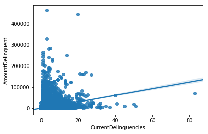

```python
##validating the other two numerical values relationship.
sb.regplot(data = Loans, x = 'CurrentDelinquencies', y = 'AmountDelinquent')
```

'CurrentDelinquencies','AmountDelinquent has smiler co-relation as per diagram.

Now, let's take a second look categorical variables against loan Amount,Interest Rate and carat again, this time

```python
# compute the logarithm of price to make multivariate plotting easier
def log_trans(x, inverse = False):
    """ quick function for computing log and power operations """
    if not inverse:
        return np.log10(x)
    else:
        return np.power(10, x)

Loans['Log_LoanAmount'] = Loans['LoanOriginalAmount'].apply(log_trans)
```

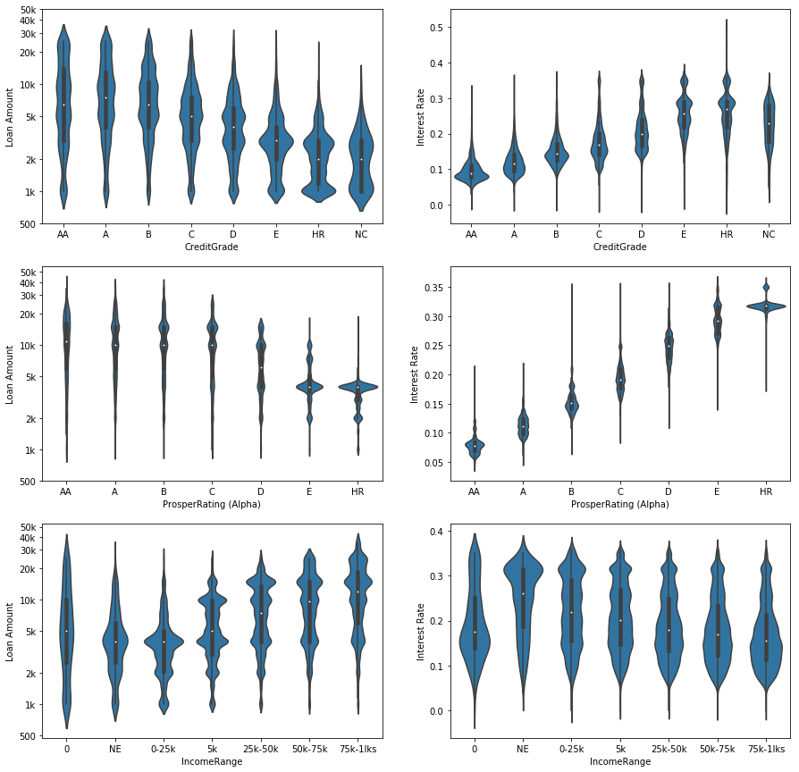

```python
# plot the categorical variables against loan Amount,Interest Rate and carat again, this time
# with full data and variable transforms
fig, ax = plt.subplots(ncols = 2, nrows = 3 , figsize = [15,15])
categoric_vars =['CreditGrade','ProsperRating (Alpha)','IncomeRange']

for i in range(len(categoric_vars)):
    var = categoric_vars[i]
    sb.violinplot(data = Loans, x = var, y = 'Log_LoanAmount', ax = ax[i,0],
               color = default_color)
    ax[i,0].set_yticks(log_trans(np.array([500, 1e3, 2e3, 5e3, 1e4, 2e4,3e4,4e4,5e4])))
    ax[i,0].set_yticklabels([500, '1k', '2k', '5k', '10k', '20k','30k','40k','50k'])
    if var =="IncomeRange":
        ax[i,0].set_xticklabels(['0', 'NE', '0-25k', '5k', '25k-50k', '50k-75k','75k-1lks','>1lks'])

    ax[i,0].set_ylabel('Loan Amount')
    sb.violinplot(data = Loans, x = var, y = 'BorrowerRate', ax = ax[i,1],
               color = default_color)
    ax[i,1].set_ylabel('Interest Rate')
    if var =="IncomeRange":
        ax[i,1].set_xticklabels(['0', 'NE', '0-25k', '5k', '25k-50k', '50k-75k','75k-1lks','>1lks'])
plt.show()
```

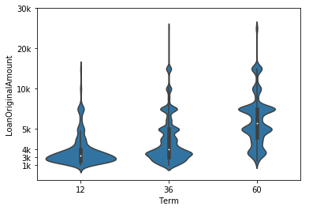

```python
#Let's see which term borrowers choose for loans
base_color = sb.color_palette()[0]
sb.violinplot(data = Loans, y = 'LoanOriginalAmount', x = 'Term', color = base_color)
plt.yticks([1e3,3e3,5e3, 1e4, 2e4,3e4,4e4], ['1k','3k', '4k', '5k', '10k', '20k','30k','40k']);
```

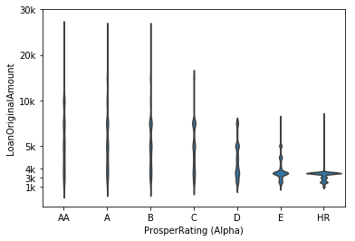

```python
# Quick review about Loan Amout and Proper rating
base_color = sb.color_palette()[0]
sb.violinplot(data = Loans, y = 'LoanOriginalAmount', x = 'ProsperRating (Alpha)', color = base_color,
              inner = None)
plt.yticks([1e3,3e3,5e3, 1e4, 2e4,3e4,4e4], ['1k','3k', '4k', '5k', '10k', '20k','30k','40k']);
```

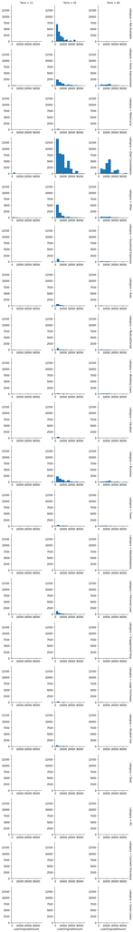

```python
## overview of purpose of the loan & Amount & term destribution
g = sb.FacetGrid(data = Loans, col = 'Term', row = 'category', size = 2.5,
                margin_titles = True)
g.map(plt.hist, "LoanOriginalAmount");
```

### Talk about some of the relationships you observed in this part of the investigation. How did the feature(s) of interest vary with other features in the dataset?

There was also an interesting relationship observed between Interest Rate and the categorical features. For Prosper rating , Credit ratings are heavily impacting interest rate. The barrower getting small amount of money if they have lowest credit score.

### Did you observe any interesting relationships between the other features (not the main feature(s) of interest)?

Expected relationships were found in the association between the 'Credit rating', 'Prosper Rating', and 'Term' which makes impacting the interest rate.